# Sixth Week: Linear Models

House price prediction

Mohammadmahdi Faryabi - STD-ID: 93101951

2018-04-13 21:21:50

> با توجه به داده های قیمت منازل لطفا با سوالات زیر پاسخ دهید.

> Loading required libraries and data files:

```r
library(readr)
library(dplyr)
```

```r
library(ggplot2)
library(highcharter)
library(tidyr)

test_data <- read_csv('../../house/test.csv')
train_data <- read_csv('../../house/train.csv')
```

۱. ماتریس همبستگی متغیرهای مختلف را به دست آورده و سپس رسم نمایید. اعداد به دست آمده را با آزمون فرض معناداری همبستگی بسنجید و سپس ده متغیری که همبستگی بالاتری با قیمت دارند را مشخص نمایید.

> First we’ve selected only numeric columns for the calculations since using the categorical data in a linear regression model is not suitable.  
> Then we’ve removed the Id column from data since it is a dummy attribute and does’nt relate to our model.  
> Then we’ve calculated pairwire correlation beased on complete observation pairs in dataset and created the correlation matrix.  
> We are only interested in correlations with SalePrice, so we’ve selected the 10 most correlated variables with the SalePrice excluding itself (correlation of an RV with itself is 1).  
> This data will become useful in the following questions.  
> After that we’ve visualized correlation matrix in three ways. first is a heatmap visualization. second is another vaiant of heatmap and the third is second visualization augmented with the results of meaningfullness test.  
> The confidence level for the conducted test is 95% and the significance level os 2e-16.

```r
################################################################################################
#### Q1

train_data %>% select_if(is.numeric) %>% select(-Id) -> q1_data
q1_data %>% cor(use = "pairwise.complete.obs") -> q1_cor
q1_cor %>% as.data.frame() %>% select(SalePrice) %>% cbind(Factor=rownames(.)) %>%
  arrange(desc(SalePrice)) %>% slice(2:11) -> q1_top_factors


q1_top_factors %>% select(Factor) %>% .$Factor %>% as.character() -> top_factors
q1_top_factors %>% print()
```

```
## # A tibble: 10 x 2
##    SalePrice Factor
##        <dbl> <fct>
##  1     0.791 OverallQual
##  2     0.709 GrLivArea
##  3     0.640 GarageCars
##  4     0.623 GarageArea
##  5     0.614 TotalBsmtSF
##  6     0.606 1stFlrSF
##  7     0.561 FullBath
##  8     0.534 TotRmsAbvGrd
##  9     0.523 YearBuilt
## 10     0.507 YearRemodAdd
```

```r
q1_cor %>% hchart()
```

[interactive chart not shown]

```r
library(psych)
```

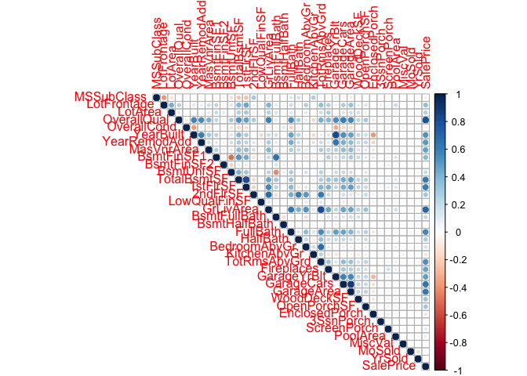

```r
# q1_data %>% corr.test() %>% .$p %>% print()

library(corrplot)
q1_data %>% cor.mtest(conf.level = .95) -> res1
q1_cor %>% corrplot(type = 'upper')
```

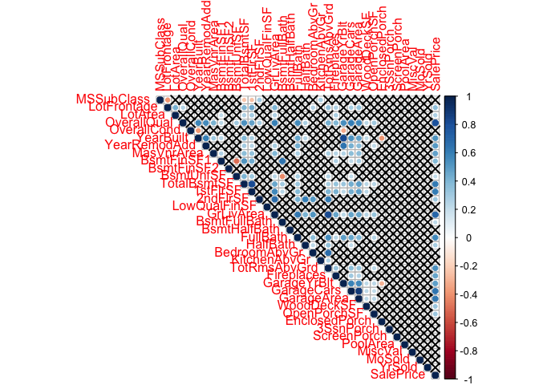

```r
q1_cor %>% corrplot(type = 'upper', p.mat = res1$p, sig.level = 2e-16, pch.cex = 1.5)
```

۲. در یک تصویر نمودار پراکنش دو به دو ده متغیر بدست آمده به همراه قیمت را رسم نمایید و هم خطی بودن متغیرها را بررسی کنید

> For this question, we’ve added SalePrice column to the data frame of its 10 most correlated factors and drawn a separate diagram for each pair of the 11 factors.  
> The result is 55 distinct diagrams.  
> From the looks of this diagram we can say all of the factors have more or less, some linear like relation with SalePrice.  
> Some of the more obvious ones are OverallQual and GrLiveArea and some of the less obvious ones are FullBath and TotRmsAbvGrd.

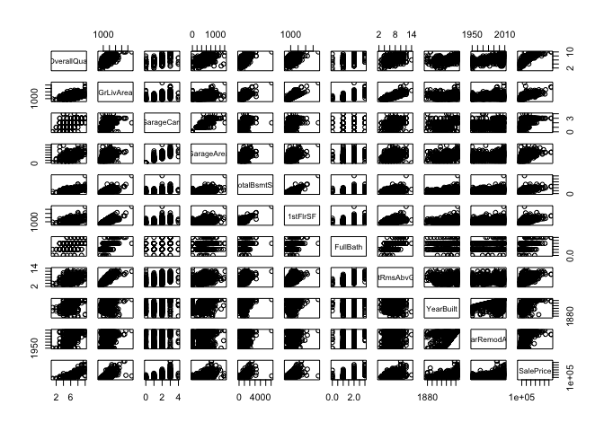

```r
################################################################################################
#### Q2

train_data %>% select(c(top_factors, 'SalePrice')) %>% plot()
```

۳. یک مدل خطی بر اساس ده متغیر برای پیش بینی قیمت برازش دهید. و سپس خلاصه نتایج مدل را به دست آورید.

> We’ve developed this model using linear regression and the 10 variables we’ve just found.  
> By looking at model’s summary we can infer that we cannot reject the null hypothesis that some of the variables in the model are effective. so some of them including ‘GarageArea’, ‘TotRmsAbvGrd’ and ‘FullBath’ may not play a considerable role in our model.  
> The model’s degree of freedom is 1449 and has a relatively high adjusted R^2 value. showing that The ‘linear’ modeling probably is not a bad choice.  
> The high F Statistics of the model on a relatively large number of data indicates that the hypothesis of all the parameters being zero (except intercept) is rejected.

```r
################################################################################################
#### Q3

library(magrittr)
train_data %>% select(c(top_factors, 'SalePrice')) %$% lm(SalePrice ~ ., .) -> q3_lm
q3_lm %>% summary() %>% print()
```

```
##
## Call:
## lm(formula = SalePrice ~ ., data = .)
##
## Residuals:
##     Min      1Q  Median      3Q     Max
## -489958  -19316   -1948   16020  290558
##
## Coefficients:
##                Estimate Std. Error t value Pr(>|t|)
## (Intercept)  -1.186e+06  1.291e+05  -9.187  < 2e-16 ***
## OverallQual   1.960e+04  1.190e+03  16.472  < 2e-16 ***
## GrLivArea     5.130e+01  4.233e+00  12.119  < 2e-16 ***
## GarageCars    1.042e+04  3.044e+03   3.422 0.000639 ***
## GarageArea    1.495e+01  1.031e+01   1.450 0.147384
## TotalBsmtSF   1.986e+01  4.295e+00   4.625 4.09e-06 ***
## `1stFlrSF`    1.417e+01  4.930e+00   2.875 0.004097 **
## FullBath     -6.791e+03  2.682e+03  -2.532 0.011457 *
## TotRmsAbvGrd  3.310e+01  1.119e+03   0.030 0.976404
## YearBuilt     2.682e+02  5.035e+01   5.328 1.15e-07 ***
## YearRemodAdd  2.965e+02  6.363e+01   4.659 3.47e-06 ***
## ---
## Signif. codes:  0 '***' 0.001 '**' 0.01 '*' 0.05 '.' 0.1 ' ' 1
##
## Residual standard error: 37920 on 1449 degrees of freedom
## Multiple R-squared:  0.7737, Adjusted R-squared:  0.7721
## F-statistic: 495.4 on 10 and 1449 DF,  p-value: < 2.2e-16
```

۴. نمودار قیمت واقعی و قیمت پیش بینی را رسم نمایید و خوب بودن مدل را ارزیابی کنید.

> We’ve drawn the diagram of predicted prices vs actual prices in a scatter plot.  
> In the first glance it looks like there might be a non linear element in the model.  
> In order to further analyse the results we’ve drawn the scatter plot of the residuals vs the actual price.  
> This plot shows that the residuals increase as the real price increases. so the model is not that good yet and error variance is not constant across all the price domain.

```r
################################################################################################
#### Q4

cbind(
  PredictedPrice = predict.lm(q3_lm, train_data %>% select(c(top_factors))),
  train_data %>% select(SalePrice)
) %>% hchart(type = 'point', hcaes(x = PredictedPrice, y = SalePrice))
```

[interactive chart not shown]

```r
cbind(
  Residuals = residuals(q3_lm),
  train_data %>% select(SalePrice)
) %>% hchart(type = 'point', hcaes(y = Residuals, x = SalePrice), color = 'red')
```

[interactive chart not shown]

۵. مقدار R-squared مدل را به دست آورید. آیا بر اساس این کمیت مدل به خوبی به داده ها برازش داده شده است؟ کمیت F-statistic را در خلاصه مدل تفسیر نمایید.

> The model has a relatively high adjusted R^2 value. showing that The ‘linear’ modeling probably is not a bad choice and mostly cover’s the distribution of data.  
> The high F Statistics of the model on a relatively large number of data indicates that the hypothesis of all the parameters being zero (except intercept) is rejected.  
> So there is at least one non-zero model parameter.

```r
###############################################################################################
#### Q5

# q3_lm %>% summary() %>% print()

q3_lm %>% summary() %>% .$fstatistic
```

```
##     value     numdf     dendf
##  495.3802   10.0000 1449.0000
```

```r
q3_lm %>% summary() %>% .$r.squared
```

```
## [1] 0.7736928
```

```r
q3_lm %>% summary() %>% .$adj.r.squared
```

```
## [1] 0.772131
```

۶. بر اساس p-value سطح معناداری ضرایب تصمیم بگیرید که چه متغیرهایی در مدل سازی استفاده شود. بر اساس متغیرهای جدید دوباره مدل سازی کنید و نتایج رو گزارش دهید.

> Considering the p-value of level of significance of the model parameters we’ve decided to not use the four less significant valriables in our model.  
> These four variable are ‘GarageArea’, ‘TotRmsAbvGrd’, ‘FullBath’ and ‘1stFlrSF’.  
> The reslting model is then summarised and the scatter plots of predicted prices and residuals vs actual prices are drawn.

```r
###############################################################################################
#### Q6

train_data %>% select(c(top_factors, 'SalePrice')) %>%
  select(-GarageArea, -TotRmsAbvGrd, -FullBath, -`1stFlrSF`) -> q6_data

q6_data %$% lm(SalePrice ~ ., .) -> q6_lm

q6_lm %>% summary() %>% print()
```

```
##
## Call:
## lm(formula = SalePrice ~ ., data = .)
##
## Residuals:
##     Min      1Q  Median      3Q     Max
## -477106  -19737   -2015   16452  290098
##
## Coefficients:
##                Estimate Std. Error t value Pr(>|t|)
## (Intercept)  -1.053e+06  1.218e+05  -8.650  < 2e-16 ***
## OverallQual   1.912e+04  1.186e+03  16.123  < 2e-16 ***
## GrLivArea     5.036e+01  2.551e+00  19.743  < 2e-16 ***
## GarageCars    1.439e+04  1.813e+03   7.939 4.03e-15 ***
## TotalBsmtSF   3.086e+01  2.811e+00  10.979  < 2e-16 ***
## YearBuilt     2.211e+02  4.802e+01   4.605 4.49e-06 ***
## YearRemodAdd  2.757e+02  6.353e+01   4.340 1.52e-05 ***
## ---
## Signif. codes:  0 '***' 0.001 '**' 0.01 '*' 0.05 '.' 0.1 ' ' 1
##
## Residual standard error: 38100 on 1453 degrees of freedom
## Multiple R-squared:  0.7709, Adjusted R-squared:   0.77
## F-statistic:   815 on 6 and 1453 DF,  p-value: < 2.2e-16
```

```r
cbind(
  PredictedPrice = predict.lm(q6_lm, train_data %>% select(c(top_factors))),
  train_data %>% select(SalePrice)
) %>% hchart(type = 'point', hcaes(x = PredictedPrice, y = SalePrice))
```

[interactive chart not shown]

```r
cbind(
  Residuals = residuals(q6_lm),
  train_data %>% select(SalePrice)
) %>% hchart(type = 'point', hcaes(y = Residuals, x = SalePrice), color = 'red')
```

[interactive chart not shown]

۷. مدل خود را بر اساس باقی مانده نقص یابی کنید. سه محک normality, independance, Constant Variance را در نقص یابی خود در نظر بگیرید.

```r
###############################################################################################
#### Q7

#### Constant variance

q6_data %>% mutate(SalePriceLog = log(SalePrice)) -> q7_data
lm(SalePriceLog ~ . - SalePrice, q7_data) -> q7_lm

q7_lm %>% summary() %>% print()
```

```
##
## Call:
## lm(formula = SalePriceLog ~ . - SalePrice, data = q7_data)
##
## Residuals:
##      Min       1Q   Median       3Q      Max
## -2.17204 -0.07530  0.00812  0.09233  0.53923
##
## Coefficients:
##               Estimate Std. Error t value Pr(>|t|)
## (Intercept)  3.118e+00  5.442e-01   5.730 1.22e-08 ***
## OverallQual  9.298e-02  5.300e-03  17.542  < 2e-16 ***
## GrLivArea    2.363e-04  1.140e-05  20.731  < 2e-16 ***
## GarageCars   8.683e-02  8.101e-03  10.719  < 2e-16 ***
## TotalBsmtSF  1.305e-04  1.256e-05  10.389  < 2e-16 ***
## YearBuilt    1.733e-03  2.146e-04   8.074 1.41e-15 ***
## YearRemodAdd 2.153e-03  2.839e-04   7.583 5.98e-14 ***
## ---
## Signif. codes:  0 '***' 0.001 '**' 0.01 '*' 0.05 '.' 0.1 ' ' 1
##
## Residual standard error: 0.1703 on 1453 degrees of freedom
## Multiple R-squared:  0.8191, Adjusted R-squared:  0.8183
## F-statistic:  1096 on 6 and 1453 DF,  p-value: < 2.2e-16
```

```r
cbind(
  PredictedPrice = fitted.values(q7_lm) %>% exp(),
  q7_data %>% select(SalePrice)
) %>% hchart(type = 'point', hcaes(x = PredictedPrice, y = SalePrice))
```

[interactive chart not shown]

```r
cbind(
  ((fitted.values(q7_lm) %>% exp()) - (q7_data %>% select(SalePrice))) %>% rename(Residuals = SalePrice),
  q7_data %>% select(SalePrice)
) %>% hchart(type = 'point', hcaes(y = Residuals, x = SalePrice), color = 'red')
```

[interactive chart not shown]

```r
#### using VIF for independence test
library(car)
q6_lm %>% vif() %>% print()
```

```
##  OverallQual    GrLivArea   GarageCars  TotalBsmtSF    YearBuilt
##     2.704116     1.805732     1.844324     1.528248     2.114612
## YearRemodAdd
##     1.728871
```

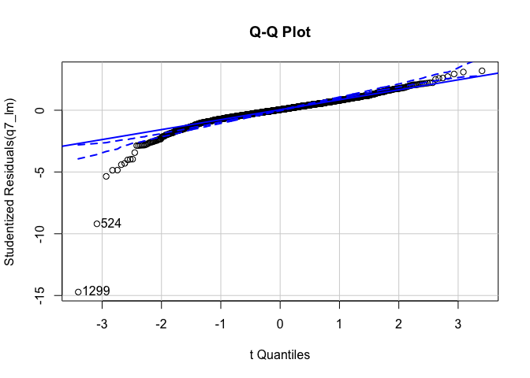

```
## [1]  524 1299
```

```r
#### using qqPlot for normality test
car::qqp(q7_lm, id.method="identify", simulate = TRUE, main="Q-Q Plot")
```

۸. داده ها را به پنج قسمت تقسیم کنید. بر اساس چهار قسمت مدل خطی را بسازید و صحت مدل را برای یک قسمت باقی مانده را تست کنید. خطای پیش بینی شما چقدر است؟

```r
###############################################################################################
#### Q8

n <- nrow(q7_data)
q8_train_index <- sample(1:n, 0.8*n)
q8_test_index <- setdiff(1:n, q8_train_index)

q8_train_data <- q7_data[q8_train_index,]
q8_test_data <- q7_data[q8_test_index,]

lm(SalePriceLog ~ . - SalePrice, q8_train_data) -> q8_lm


cbind(
  PredictedPrices = predict.lm(q8_lm, q8_test_data) %>% exp(),
  q8_test_data %>% select(SalePrice)
) %>% hchart(type = 'point', hcaes(x = PredictedPrices, y = SalePrice))
```

[interactive chart not shown]

```r
cbind(
  ((predict(q8_lm, q8_test_data) %>% exp()) - (q8_test_data %>% select(SalePrice))) %>% rename(Residuals = SalePrice),
  q8_test_data %>% select(SalePrice)
) -> q8_residual_data

q8_residual_data %>% hchart(type = 'point', hcaes(y = Residuals, x = SalePrice), color = 'red')
```

[interactive chart not shown]

```r
q8_residual_data_vector <- q8_residual_data %>% select(Residuals) %>% .$Residuals

q8_mu <- mean(q8_residual_data_vector)
q8_sd <- sd(q8_residual_data_vector)

q8_mu %>% print()
```

```
## [1] -3120.577
```

```r
q8_sd %>% print()
```

```
## [1] 30925.97
```

۹. آیا قیمت ربط غیر خطی با یکی از ده متغیر استفاده شده دارد؟ بر اساس دستاوردهای خود مدل را بهتر نمایید.

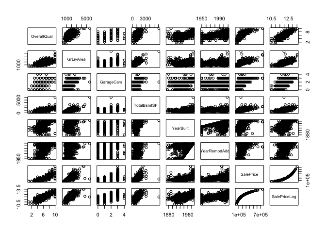

```r
###############################################################################################
#### Q9


# I will compare model variables agains one another in order to
# observe curve similarities to non linear functions.

q7_data %>% plot()
```

```r
# 'TotalBsmtSF' vs Sale price is a sqrt-like function and 'GrLivArea' is a log-like function.
# I think there is no more obvios non linearity evidences.

# Now I recreate the mlodel and use this non linear relations instead:

# q7_data[which(q7_data$TotalBsmtSF == 0),]$TotalBsmtSF = 1
q9_lm <- lm(SalePriceLog ~ OverallQual + I(log(GrLivArea)) +
              GarageCars + YearRemodAdd + YearBuilt + I(sqrt(TotalBsmtSF)), q7_data)

q9_lm %>% summary()
```

```
##
## Call:
## lm(formula = SalePriceLog ~ OverallQual + I(log(GrLivArea)) +
##     GarageCars + YearRemodAdd + YearBuilt + I(sqrt(TotalBsmtSF)),
##     data = q7_data)
##
## Residuals:
##      Min       1Q   Median       3Q      Max
## -1.46995 -0.07939  0.00682  0.09923  0.51807
##
## Coefficients:
##                       Estimate Std. Error t value Pr(>|t|)
## (Intercept)          0.5290820  0.5510707   0.960    0.337
## OverallQual          0.0855290  0.0051667  16.554  < 2e-16 ***
## I(log(GrLivArea))    0.4162106  0.0173709  23.960  < 2e-16 ***
## GarageCars           0.0805158  0.0078612  10.242  < 2e-16 ***
## YearRemodAdd         0.0020427  0.0002739   7.459 1.49e-13 ***
## YearBuilt            0.0017676  0.0002047   8.637  < 2e-16 ***
## I(sqrt(TotalBsmtSF)) 0.0084593  0.0006581  12.854  < 2e-16 ***
## ---
## Signif. codes:  0 '***' 0.001 '**' 0.01 '*' 0.05 '.' 0.1 ' ' 1
##
## Residual standard error: 0.1645 on 1453 degrees of freedom
## Multiple R-squared:  0.8311, Adjusted R-squared:  0.8304
## F-statistic:  1191 on 6 and 1453 DF,  p-value: < 2.2e-16
```

```r
cbind(
  PredictedPrices = predict.lm(q9_lm, q8_test_data) %>% exp(),
  q8_test_data %>% select(SalePrice)
) %>% hchart(type = 'point', hcaes(x = PredictedPrices, y = SalePrice))
```

[interactive chart not shown]

```r
cbind(
  ((predict(q9_lm, q8_test_data) %>% exp()) - (q8_test_data %>% select(SalePrice))) %>% rename(Residuals = SalePrice),
  q8_test_data %>% select(SalePrice)
) -> q9_residual_data

q9_residual_data %>% hchart(type = 'point', hcaes(y = Residuals, x = SalePrice), color = 'red')
```

[interactive chart not shown]

```r
q9_residual_data_vector <- q9_residual_data %>% select(Residuals) %>% .$Residuals

q9_mu <- mean(q9_residual_data_vector)
q9_sd <- sd(q9_residual_data_vector)

q9_mu %>% print()
```

```
## [1] -2901.773
```

```r
q9_sd %>% print()
```

```
## [1] 33611.49
```

۱۰. بر اساس مدل نهایی به دست آمده نتایج پیش بینی خود را بر روی test.csv به دست آورید و در سایت kaggle در مسابقه House Prices: Advanced Regression Techniques بارگذاری نمایید. سپس لینک رتبه و عدد آن را ضمیمه تمرین کنید.

> The kernel is built, and the result submitted.  
> The ‘Public Score’ is 0.16548  
> The rank is 2960 out of 4795 at the time of writing this report  
> Link to public kernel page:  
> https://www.kaggle.com/faryabimm/kernela5b4857479/  
> Kaggle kernel script file is also included with the report. please look for the file ‘HW6_kaggle_version.R’

```r
###############################################################################################
#### Q10

# predict(q9_lm, test_data) %>% exp() %>% View()
```

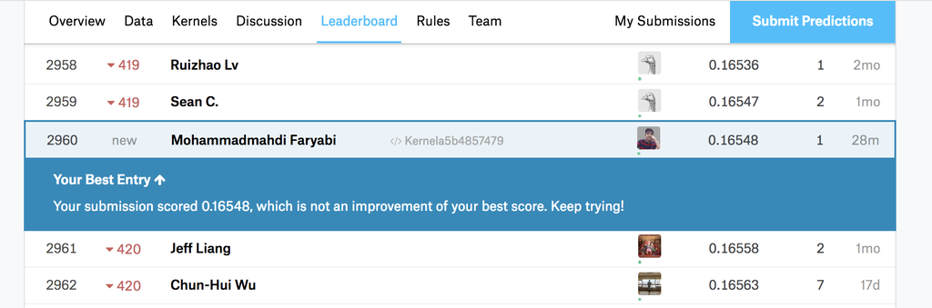